# Chap 8.6-8.7

Mijeong Kim

```r
library(tsibble)
library(tsibbledata)
library(tibble)
library(dplyr)
library(knitr)
library(ggplot2)
library(fpp3)
library(fpp2)
library(seasonal)
library(feasts)
```

## 8.6 Estimation and model selection (추정과 모델 선택)

### ETS 모델의 모수 추정 (Estimating ETS Models)

#### 모수 추정 방법

- **최소제곱합(SSE, Sum of Squared Errors) 최소화** 대신  
  **우도(likelihood) 최대화**를 통해 추정할 수 있음.
- 가법 오차 모델(additive errors)에서는 두 방법이 동일한 결과를 줌.
- 승법 오차 모델(multiplicative errors)에서는 서로 다른 결과를 낳을 수 있음.

#### 추정 대상

- 평활 계수 (Smoothing parameters):
  $$\alpha, \quad \beta, \quad \gamma, \quad \phi$$
- 초기 상태 (Initial states):
  $$\ell_0, \quad b_0, \quad s_0, \quad s_{-1}, \quad \ldots, \quad s_{-m+1}$$

#### 평활 계수의 제약 조건 (Traditional Restrictions)

- 일반 제약:
  $$0 < \alpha, \, \beta^*, \, \gamma^*, \, \phi < 1$$
- 상태공간모형 변환:
  $$\beta = \alpha \beta^*, \quad \gamma = (1-\alpha) \gamma^*$$
- 이에 따른 제약:
  $$0 < \alpha < 1, \quad 0 < \beta < \alpha, \quad 0 <
  \gamma < 1-\alpha$$
- 감쇠 파라미터(ϕ)는 수치적 안정성을 위해 추가로 제약:
  $$0.8 < \phi < 0.98 \quad \text{(fable 패키지 기준)}$$

#### 수학적 성질 기반 제약 (Admissibility Constraints)

- 목적: 과거 관측값이 현재 예측에 지속적인 영향을 미치는 것을 방지.
- 예시:
  - **ETS(A,N,N)**:
    - 전통적 제약: $0 < \alpha < 1$
    - 허용 가능한(admissible) 영역: $0 < \alpha < 2$
  - **ETS(A,A,N)**:
    - 전통적 제약: $0 < \alpha < 1, \, 0 < \beta < \alpha$
    - 허용 가능한 영역: $0 < \alpha < 2, \, 0 < \beta < 4-2\alpha$

### 모델 선택 (Model Selection)

#### 정보 기준을 이용한 모델 선택

- ETS 통계 프레임워크의 강점: **정보 기준(Information Criteria)**를 활용한 모델 선택 가능.
- 사용 가능한 기준:
  - **AIC (Akaike Information Criterion)**:
    $$AIC = -2\log(L) + 2k$$
  - **AICc (Small sample corrected AIC)**:
    $$AICc = AIC + \frac{2k(k+1)}{T-k-1}$$
  - **BIC (Bayesian Information Criterion)**:
    $$BIC = AIC + k[\log(T) - 2]$$
- 여기서:
  - $L$ = 모델의 우도(likelihood)
  - $k$ = 추정된 파라미터 및 초기 상태(state)의 수
  - $T$ = 표본 크기

#### 수치적 불안정성을 일으킬 수 있는 모델

- 다음 모델들은 수치적 불안정성(numerical instability)을 일으킬 수 있어 제외:
  - ETS(A,N,M)
  - ETS(A,A,M)
  - ETS(A,Aᵈ,M)
- 원인: 상태 방정식에서 0에 가까운 값으로 나누기가 발생할 수 있음.

#### 승법 오차 모델의 제한사항

- 승법 오차(multiplicative error) 모델은 **자료가 양수(positive)**일 때만 적합.
- 자료에 0이나 음수 값이 포함되면 승법 오차 모델은 사용하지 않음.
- 이 경우, **6개의 가법 오차(additive error) 모델**만 적용.

### Example: Domestic holiday tourist visitor nights in Australia

```r
aus_holidays <- tourism |>
  filter(Purpose == "Holiday") |>
  summarise(Trips = sum(Trips)/1e3)
fit <- aus_holidays |>
  model(ETS(Trips))
report(fit)
```

```
## Series: Trips
## Model: ETS(M,N,A)
##   Smoothing parameters:
##     alpha = 0.3484054
##     gamma = 0.0001000018
##
##   Initial states:
##      l[0]       s[0]      s[-1]      s[-2]    s[-3]
##  9.727072 -0.5376106 -0.6884343 -0.2933663 1.519411
##
##   sigma^2:  0.0022
##
##      AIC     AICc      BIC
## 226.2289 227.7845 242.9031
```

#### 선택된 모델

- 선택된 모델: **ETS(M,N,A)** (Multiplicative Error, No Trend, Additive Seasonality)
- 모델 방정식:
  - 관측 방정식:
    $$y_t = (\ell_{t-1} + s_{t-m})(1 + \varepsilon_t)$$
  - 수준 방정식:
    $$\ell_t = \ell_{t-1} + \alpha (\ell_{t-1} + s_{t-m})\varepsilon_t$$
  - 계절성 방정식:
    $$s_t = s_{t-m} + \gamma (\ell_{t-1} + s_{t-m})\varepsilon_t$$

#### 추정된 파라미터

- $\hat{\alpha} = 0.3484$
- $\hat{\gamma} = 0.0001$

#### 초기 상태 추정값

- 추정된 초기 상태:
  - 수준($\ell_0$)
  - 계절성($s_0, s_{-1}, s_{-2}, s_{-3}$)

#### 모델 해석

- Figure 8.10: 시간에 따른 상태(state) 변화를 시각화.
- Figure 8.12: 포인트 예측(point forecasts) 및 예측 구간(prediction intervals) 제시.
- **γ 값이 매우 작아** 계절성 상태(seasonal states)는 시간이 지나도 거의 변하지 않음.

#### 비교

- Holt-Winters 방법 (additive seasonality, Table 8.3) 결과와 초기 상태 및 예측 결과를 비교 가능.

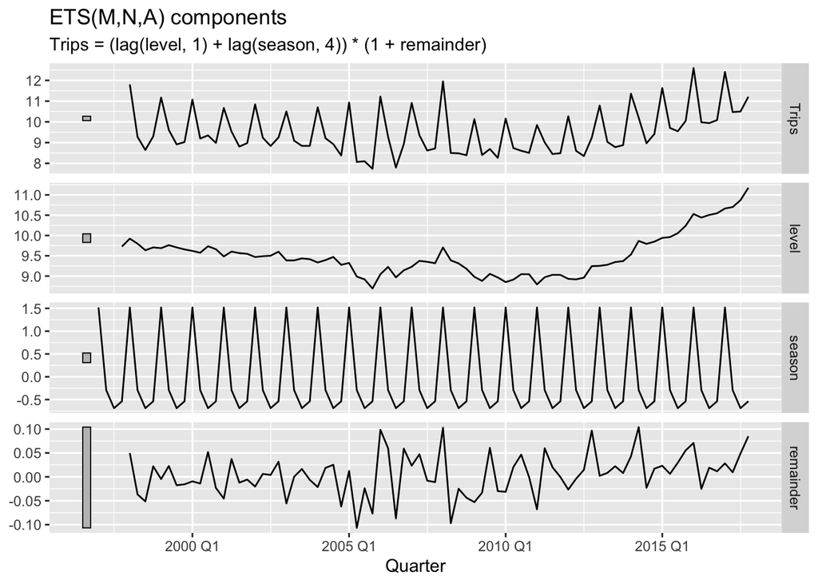

```r
components(fit) |>
  autoplot() +
  labs(title = "ETS(M,N,A) components")
```

Figure 8.10: Graphical representation of the estimated states over time.

#### 잔차 종류

- **혁신 잔차(Innovation residuals)**:
  $$\hat{\varepsilon}_t$$
- **일반 잔차(Regular residuals)** (one-step training errors):
  $$y_t - \hat{y}_{t|t-1}$$
- 승법 오차(Multiplicative errors) 모델에서는 두 잔차가 동일하지 않음.
- 승법 오차 모델에서는 **잔차 해석 시 주의**가 필요하며,  
  두 잔차를 구분하여 분석해야 함.

#### 잔차 추출 방법

- `augment()` 함수를 사용하여 **혁신 잔차**와 **일반 잔차**를 모두 추출 가능.

## 8.7 Forecasting with ETS models (ETS 모델로 예측하기)

#### 포인트 예측 계산 방법

- 예측 시점 $t = T+1, \dots, T+h$ 동안  
  모든 $\varepsilon_t = 0$으로 가정하여 방정식을 반복(iterate)하여 계산.
- 예시: **ETS(M,A,N)** 모델
  - $T+1$ 시점 예측:
    $$\hat{y}_{T+1|T} = \ell_T + b_T$$
  - $T+2$ 시점 예측:
    $$\hat{y}_{T+2|T} = \ell_T + 2b_T$$
  - 이후도 같은 방식으로 진행.

#### 특성

- ETS(M,A,N), ETS(A,A,N), Holt 선형 방법 모두 **동일한 포인트 예측 결과** 생성  
  (동일한 파라미터 값 사용 시).
- ETS 모델의 포인트 예측은 **예측 분포의 평균값**에 해당함.  
  단, **승법 계절성(multiplicative seasonality)**을 포함하는 경우는 예외.

#### R에서 예측 방법

- `fable` 패키지의 `forecast()` 함수 사용.
- 이 함수는 항상 **예측 분포의 평균값**을 반환함 (전통적 포인트 예측과 다를 수 있음).

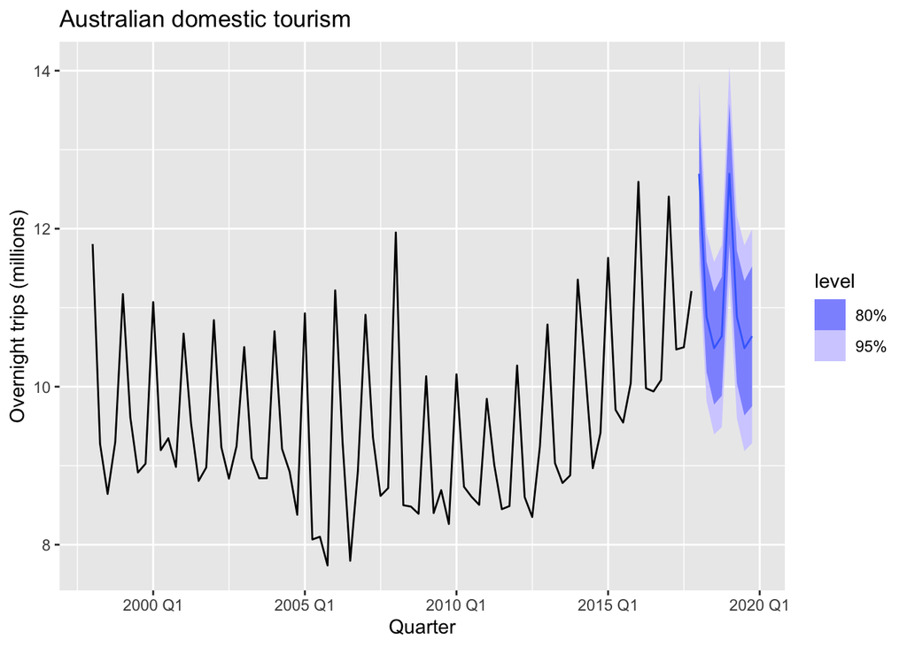

```r
fit |>
  forecast(h = 8) |>
  autoplot(aus_holidays)+
  labs(title="Australian domestic tourism",
       y="Overnight trips (millions)")
```

Figure 8.12: Forecasting Australian domestic overnight trips using an ETS(M,N,A) model.

### Prediction intervals (예측구간)

#### 통계적 모델의 장점

- ETS 통계 모델은 **예측 구간(prediction intervals)**도 생성 가능.
- 이는 단순 포인트 예측(point forecasting methods)만으로는 불가능한 기능.

#### 예측 구간 공식 (대부분의 ETS 모델)

- 기본 형태:
  $$\hat{y}_{T+h|T} \pm c \sigma_h$$
- 여기서:
  - $c$: 커버리지 확률(coverage probability)에 따라 결정 (Table 5.1 참조)
  - $\sigma_h^2$: 예측 분산(forecast variance)

#### 모델별 차이

- **가법적 오차 모델(additive errors)**과 **승법적 오차 모델(multiplicative errors)** 간에 예측 구간은 달라짐.
- 특히, 승법 오차 모델에서는 예측 구간이 비대칭 형태를 가질 수 있음.

#### 예측 분산 계산

- **ETS 모델**의 $\sigma_h^2$ 계산식은 복잡할 수 있음 (자세한 내용은 Hyndman et al., 2008, Chapter 6 참조).
- **Table 8.8**에서는 가장 단순한 경우인 **가법적 ETS 모델(additive ETS models)**에 대한 예측 분산 공식을 제공.

#### 용어 정리

- $\sigma^2$: 잔차 분산(residual variance)
- $m$: 계절 주기(seasonal period)
- $k$: $(h-1)/m$의 정수 부분 (예측 시점까지 완료된 연수)

#### Table 8.8: Forecast Variance Expressions for Various State Space Models

각각의 덧셈 상태 공간 모델에 대한 예측 분산 식입니다. 여기에서 $\sigma^2$는 잔차 분산, $m$은 계절성 주기, $k$는 $(h-1)/m$의 정수 부분 (즉, 시간 $T+h$ 앞 예측 기간에서 연도의 개수)입니다.

$$\begin{array}{|c|c|}
\hline
\textbf{모델} & \textbf{예측 분산: } \sigma_h^2 \\
\hline
(\text{A,N,N}) & \sigma^2 \left[ 1 + \alpha^2 (h-1) \right] \\
\hline
(\text{A,A,N}) & \sigma^2 \left[ 1 + (h-1)\left(\alpha^2 +
\alpha\beta h + \frac{1}{6}\beta^2 h(2h-1)\right) \right] \\
\hline
(\text{A}, A_d, \text{N}) & \sigma^2 \left[ 1 + \alpha^2 (h-1) +
\frac{\beta \phi h}{(1-\phi)^2}\left\{2\alpha(1-\phi)+\beta\phi\right\}
\right] \\
\hline
(\text{A,N,A}) & \sigma^2 \left[ 1 + \alpha^2 (h-1) + \gamma k
(2\alpha+\gamma) \right] \\
\hline
(\text{A,A,A}) & \sigma^2 \left[ 1 + (h-1)\left(\alpha^2+\alpha\beta
h+\frac{1}{6}\beta^2 h(2h-1)\right) + \gamma k (2\alpha+\gamma) +
\beta\gamma m(k+1) \right] \\
\hline
(\text{A}, A_d, \text{A}) & \sigma^2 \left[ 1 + \alpha^2 (h-1) +
\gamma k (2\alpha+\gamma) \right. \\
& \quad + \frac{\beta
\phi}{(1-\phi)^2}\left\{2\alpha(1-\phi)+\beta\phi\right\} \\
& \quad + \frac{\beta
\gamma}{(1-\phi)(1-\phi^m)}\left\{2\alpha(1-\phi)+\beta(1+2\phi-\phi^m)\right\}
\\
& \quad \left. + \frac{\beta^2
\gamma}{(1-\phi)^2(1-\phi^m)^2}\left\{k(1-\phi^m)-\phi^m(1-\phi^{mk})\right\}
\right] \\
\hline
\end{array}$$